# PRACTISE CASE EDA 1

## ANSWERED BY DWI SMARADAHANA INDRALOKA

## Import Library

```python
import numpy as np
import pandas as pd
import seaborn as sns
import matplotlib.pyplot as plt

import plotly.graph_objs as go
from plotly.offline import download_plotlyjs, init_notebook_mode, plot, iplot
```

## Upload Dataset

```python
Data = pd.read_csv("craigslistVehiclesFull.csv")
```

```python
Data.head()
```

|  | url | city | price | year | manufacturer | make | condition | cylinders | fuel | odometer | ... | paint_color | image_url | lat | long | county_fips | county_name | state_fips | state_code | state_name | weather |
| --- | --- | --- | --- | --- | --- | --- | --- | --- | --- | --- | --- | --- | --- | --- | --- | --- | --- | --- | --- | --- | --- |
| 0 | https://marshall.craigslist.org/cto/d/2010-dod... | marshall | 11900 | 2010.0 | dodge | challenger se | good | 6 cylinders | gas | 43600.0 | ... | red | https://images.craigslist.org/00i0i_2ggH1eKDNK... | 43.4775 | -96.7041 | 46083.0 | Lincoln | 46.0 | SD | South Dakota | 38.0 |
| 1 | https://marshall.craigslist.org/cto/d/fleetwoo... | marshall | 1515 | 1999.0 | NaN | fleetwood | NaN | NaN | gas | NaN | ... | NaN | https://images.craigslist.org/00M0M_irjh7SjEcU... | 44.7612 | -96.6907 | 46039.0 | Deuel | 46.0 | SD | South Dakota | 38.0 |
| 2 | https://marshall.craigslist.org/cto/d/2008-for... | marshall | 17550 | 2008.0 | ford | f-150 | NaN | NaN | gas | NaN | ... | NaN | https://images.craigslist.org/00s0s_eL2XFhEUcx... | 44.1415 | -103.2052 | 46093.0 | Meade | 46.0 | SD | South Dakota | 38.0 |
| 3 | https://marshall.craigslist.org/cto/d/ford-tau... | marshall | 2800 | 2004.0 | ford | taurus | good | 6 cylinders | gas | 168591.0 | ... | grey | https://images.craigslist.org/00L0L_5HUR1nQjt8... | 43.2845 | -95.5930 | 19143.0 | Osceola | 19.0 | IA | Iowa | 47.0 |
| 4 | https://marshall.craigslist.org/cto/d/2001-gra... | marshall | 400 | 2001.0 | NaN | 2001 Grand Prix | NaN | NaN | gas | 217000.0 | ... | NaN | https://images.craigslist.org/00n0n_bJJ1XnonSG... | 43.0261 | -94.4064 | 19109.0 | Kossuth | 19.0 | IA | Iowa | 47.0 |

5 rows × 26 columns

## Data Cleansing

### 1. Count the percentage of missing value for each field

```python
percentage = round(Data.isnull().sum()/len(Data)*100,2).sort_values(ascending = False)
percentage
```

```
size            65.23
vin             64.90
type            40.80
condition       40.67
paint_color     40.37
cylinders       40.12
drive           38.41
odometer        32.74
manufacturer     7.92
make             4.05
weather          3.45
county_fips      3.41
county_name      3.41
state_fips       3.41
state_code       3.41
fuel             0.60
transmission     0.52
year             0.37
title_status     0.15
image_url        0.00
lat              0.00
state_name       0.00
long             0.00
price            0.00
city             0.00
url              0.00
dtype: float64
```

### 2. Drop columns that contain url and missing value more than 60%

```python
Data.drop(["url", "image_url", "size", "vin"], axis = 1, inplace = True)
Data.head()
```

|  | city | price | year | manufacturer | make | condition | cylinders | fuel | odometer | title_status | ... | type | paint_color | lat | long | county_fips | county_name | state_fips | state_code | state_name | weather |
| --- | --- | --- | --- | --- | --- | --- | --- | --- | --- | --- | --- | --- | --- | --- | --- | --- | --- | --- | --- | --- | --- |
| 0 | marshall | 11900 | 2010.0 | dodge | challenger se | good | 6 cylinders | gas | 43600.0 | clean | ... | coupe | red | 43.4775 | -96.7041 | 46083.0 | Lincoln | 46.0 | SD | South Dakota | 38.0 |
| 1 | marshall | 1515 | 1999.0 | NaN | fleetwood | NaN | NaN | gas | NaN | clean | ... | NaN | NaN | 44.7612 | -96.6907 | 46039.0 | Deuel | 46.0 | SD | South Dakota | 38.0 |
| 2 | marshall | 17550 | 2008.0 | ford | f-150 | NaN | NaN | gas | NaN | clean | ... | NaN | NaN | 44.1415 | -103.2052 | 46093.0 | Meade | 46.0 | SD | South Dakota | 38.0 |
| 3 | marshall | 2800 | 2004.0 | ford | taurus | good | 6 cylinders | gas | 168591.0 | clean | ... | sedan | grey | 43.2845 | -95.5930 | 19143.0 | Osceola | 19.0 | IA | Iowa | 47.0 |
| 4 | marshall | 400 | 2001.0 | NaN | 2001 Grand Prix | NaN | NaN | gas | 217000.0 | clean | ... | NaN | NaN | 43.0261 | -94.4064 | 19109.0 | Kossuth | 19.0 | IA | Iowa | 47.0 |

5 rows × 22 columns

### 3. Drops columns that have same meaning with other columns

```python
Data.drop(["state_name", "county_fips", "state_fips"], axis = 1, inplace = True)
Data.head()
```

|  | city | price | year | manufacturer | make | condition | cylinders | fuel | odometer | title_status | transmission | drive | type | paint_color | lat | long | county_name | state_code | weather |
| --- | --- | --- | --- | --- | --- | --- | --- | --- | --- | --- | --- | --- | --- | --- | --- | --- | --- | --- | --- |
| 0 | marshall | 11900 | 2010.0 | dodge | challenger se | good | 6 cylinders | gas | 43600.0 | clean | automatic | rwd | coupe | red | 43.4775 | -96.7041 | Lincoln | SD | 38.0 |
| 1 | marshall | 1515 | 1999.0 | NaN | fleetwood | NaN | NaN | gas | NaN | clean | other | NaN | NaN | NaN | 44.7612 | -96.6907 | Deuel | SD | 38.0 |
| 2 | marshall | 17550 | 2008.0 | ford | f-150 | NaN | NaN | gas | NaN | clean | automatic | NaN | NaN | NaN | 44.1415 | -103.2052 | Meade | SD | 38.0 |
| 3 | marshall | 2800 | 2004.0 | ford | taurus | good | 6 cylinders | gas | 168591.0 | clean | automatic | fwd | sedan | grey | 43.2845 | -95.5930 | Osceola | IA | 47.0 |
| 4 | marshall | 400 | 2001.0 | NaN | 2001 Grand Prix | NaN | NaN | gas | 217000.0 | clean | automatic | NaN | NaN | NaN | 43.0261 | -94.4064 | Kossuth | IA | 47.0 |

### 4. Drop rows with more Nans than 95% quantile

```python
Data.isnull().sum(axis=1).quantile(.95)
```

```
6.0
```

```python
Data = Data[Data.isnull().sum(axis = 1) < 7]
```

### 5. Data Dimension

```python
Data.shape
```

```
(1642613, 19)
```

### 6. Data Type

```python
Data.info()
```

```
<class 'pandas.core.frame.DataFrame'>
Int64Index: 1642613 entries, 0 to 1723064
Data columns (total 19 columns):
city            1642613 non-null object
price           1642613 non-null int64
year            1636994 non-null float64
manufacturer    1545015 non-null object
make            1599607 non-null object
condition       1019954 non-null object
cylinders       1031194 non-null object
fuel            1634265 non-null object
odometer        1151177 non-null float64
title_status    1641420 non-null object
transmission    1635286 non-null object
drive           1060708 non-null object
type            1019724 non-null object
paint_color     1026379 non-null object
lat             1642613 non-null float64
long            1642613 non-null float64
county_name     1599733 non-null object
state_code      1599733 non-null object
weather         1599338 non-null float64
dtypes: float64(5), int64(1), object(13)
memory usage: 250.6+ MB
```

### 7. Rechecking the percentage of missing value for each field

```python
percentage = round(Data.isnull().sum()/len(Data)*100,2).sort_values(ascending = False)
percentage
```

```
type            37.92
condition       37.91
paint_color     37.52
cylinders       37.22
drive           35.43
odometer        29.92
manufacturer     5.94
weather          2.63
make             2.62
county_name      2.61
state_code       2.61
fuel             0.51
transmission     0.45
year             0.34
title_status     0.07
lat              0.00
long             0.00
price            0.00
city             0.00
dtype: float64
```

- Note: The missing value not be replaced with other value because this data is using for EDA

## Split Numerical Data and Categorical Data

### 1. Numerical data

```python
num_data = ["price", "odometer", "lat", "long"]
num_data = Data[num_data]
num_data.head()
```

|  | price | odometer | lat | long |
| --- | --- | --- | --- | --- |
| 0 | 11900 | 43600.0 | 43.477500 | -96.704100 |
| 2 | 17550 | NaN | 44.141500 | -103.205200 |
| 3 | 2800 | 168591.0 | 43.284500 | -95.593000 |
| 4 | 400 | 217000.0 | 43.026100 | -94.406400 |
| 5 | 9900 | 169000.0 | 43.328149 | -96.774445 |

```python
num_data.describe()
```

|  | price | odometer | lat | long |
| --- | --- | --- | --- | --- |
| count | 1.642613e+06 | 1.151177e+06 | 1.642613e+06 | 1.642613e+06 |
| mean | 9.497710e+04 | 1.138557e+05 | 3.876065e+01 | -9.358251e+01 |
| std | 9.342556e+06 | 1.370827e+05 | 5.788742e+00 | 1.683084e+01 |
| min | 1.000000e+00 | 0.000000e+00 | -8.481005e+01 | -1.799561e+02 |
| 25% | 3.475000e+03 | 5.833400e+04 | 3.492050e+01 | -1.051030e+02 |
| 50% | 7.200000e+03 | 1.070000e+05 | 3.937640e+01 | -8.816024e+01 |
| 75% | 1.499900e+04 | 1.520000e+05 | 4.250482e+01 | -8.100950e+01 |
| max | 2.032266e+09 | 1.000000e+07 | 8.451648e+01 | 1.259968e+02 |

### 2. Categorical data

```python
cat_data = Data.drop(num_data, axis = 1)
cat_data.head()
```

|  | city | year | manufacturer | make | condition | cylinders | fuel | title_status | transmission | drive | type | paint_color | county_name | state_code | weather |
| --- | --- | --- | --- | --- | --- | --- | --- | --- | --- | --- | --- | --- | --- | --- | --- |
| 0 | marshall | 2010.0 | dodge | challenger se | good | 6 cylinders | gas | clean | automatic | rwd | coupe | red | Lincoln | SD | 38.0 |
| 2 | marshall | 2008.0 | ford | f-150 | NaN | NaN | gas | clean | automatic | NaN | NaN | NaN | Meade | SD | 38.0 |
| 3 | marshall | 2004.0 | ford | taurus | good | 6 cylinders | gas | clean | automatic | fwd | sedan | grey | Osceola | IA | 47.0 |
| 4 | marshall | 2001.0 | NaN | 2001 Grand Prix | NaN | NaN | gas | clean | automatic | NaN | NaN | NaN | Kossuth | IA | 47.0 |
| 5 | marshall | 2007.0 | gmc | yukon | good | 8 cylinders | gas | clean | automatic | 4wd | NaN | NaN | Lincoln | SD | 38.0 |

## General Visualization

### 1. Number of cars in every year

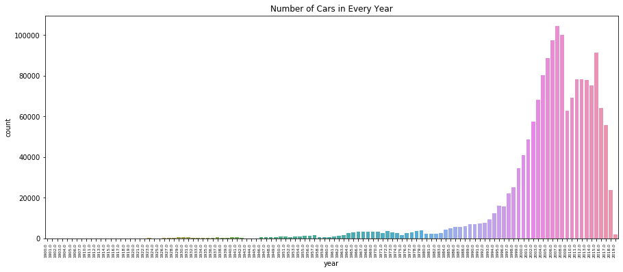

```python
plt.figure(figsize=(15,6))
ax = sns.countplot(x = "year", data = data_year);
ax.set_xticklabels(ax.get_xticklabels(), rotation = 90, ha="right",fontsize = 6)
plt.title("Number of Cars in Every Year")
ax
```

From the graphic above, we can see that the number of cars sold with year less than 1963 are very low and the number of cars with year 2009 less than he number of cars with year 2008, that can be indicate something in year 2009.

### 2. Average price of cars in every year

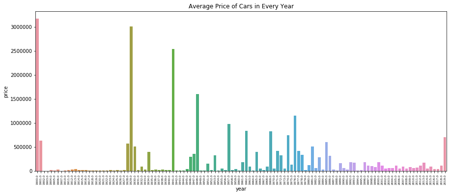

```python
con_price1 = Data[["year", "price"]].groupby("year").mean()["price"].sort_values(ascending = False)
plt.figure(figsize = (15,6))
sns.barplot(x = con_price1.index, y = con_price1)
plt.xticks(rotation = 90, fontsize = 6)
plt.title("Average Price of Cars in Every Year")
```

From the graphic above, we can see that the average price old year cars almostly higher than new year cars, it can happen because the amount of data for the old yeas cars is more or less than the amount of data for the new year cars.

### 3. Number of cars based on manufacturer

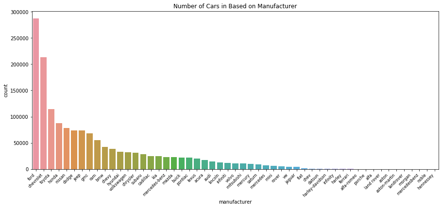

```python
plt.figure(figsize = (15, 6))
ax = sns.countplot(x = "manufacturer", data = Data, order = Data["manufacturer"].value_counts().index)
ax.set_xticklabels(ax.get_xticklabels(), rotation = 45, ha = "right",fontsize = 8)
plt.title("Number of Cars in Based on Manufacturer")
ax
```

From the graphic above, we can see that brand cars Ford wich that has the most number of cars sold and brand cars hennessey wich that has the least number of cars sold

### 4. Average price of cars based on manufacturer

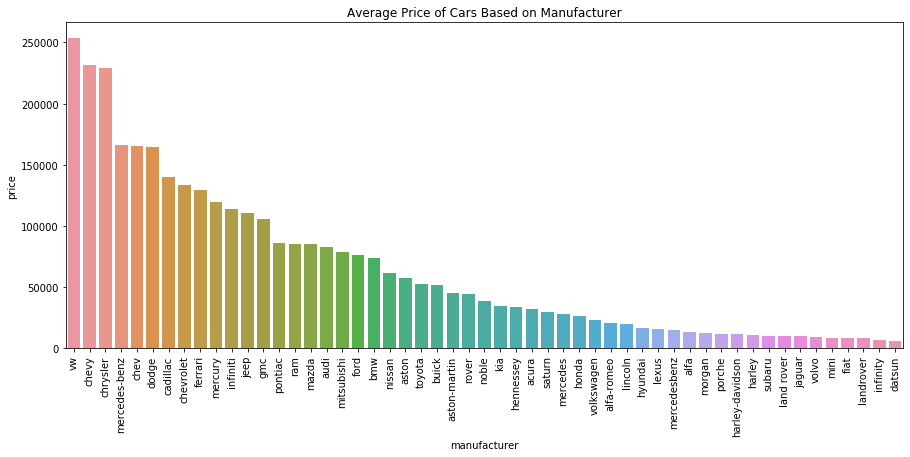

```python
con_price2 = Data[["manufacturer", "price"]].groupby("manufacturer").mean()["price"].sort_values(ascending = False)
plt.figure(figsize = (15,6))
sns.barplot(x = con_price2.index, y = con_price2)
plt.xticks(rotation = 90)
plt.title("Average Price of Cars Based on Manufacturer")
```

From the graphic above, we can see that the highest average price of cars are from VW and the lowest average price of cars are from Datsun

### 5. Number of cars in every state

```python
statecount = Data.state_code.value_counts()
datamap = dict(type = "choropleth", colorscale = "Greens", locations = statecount.index, z = statecount, locationmode = "USA-states",
               marker = dict(line = dict(color = "rgb(255,255,255)",width = 2)), colorbar = {'title':"Number of Cars per State"})
layout = dict(title = "Number of Cars per State", geo = dict(scope="usa", showlakes = True, lakecolor = "rgb(85,173,240)"))
choromap = go.Figure(data = [datamap],layout = layout)
iplot(choromap)
```

[interactive chart not shown]

From the graphic above, we can see the number of cars in every state. We can used that information to find where to buy the cars or where we can sale the cars.

## Analyzing

### 1. Price analyzing

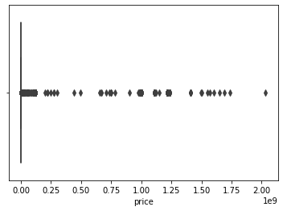

```python
sns.boxplot(Data["price"])
```

```python
num_data.price.describe()
```

```
count    1.642613e+06
mean     9.497710e+04
std      9.342556e+06
min      1.000000e+00
25%      3.475000e+03
50%      7.200000e+03
75%      1.499900e+04
max      2.032266e+09
Name: price, dtype: float64
```

Based on price analyzing there are some price that too low and too high, so we drop the data with price that lower than 3475 and higher than 15000

```python
Data.drop(Data[Data.price < 3475].index, inplace = True)
Data.drop(Data[Data.price > 15000].index, inplace = True)
```

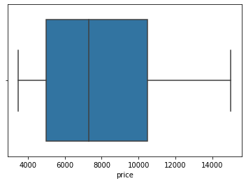

```python
sns.boxplot(Data["price"])
```

```python
percentage = round(Data.isnull().sum()/len(Data)*100,2).sort_values(ascending = False)
percentage
```

```
type            36.85
paint_color     36.67
condition       35.39
cylinders       34.67
drive           34.50
odometer        27.37
manufacturer     5.14
make             2.34
weather          2.19
county_name      2.18
state_code       2.18
transmission     0.49
fuel             0.36
year             0.27
title_status     0.08
lat              0.00
long             0.00
price            0.00
city             0.00
dtype: float64
```

### 2. Finding numerical variable that affect the price

### 2.1 Price VS Odometer

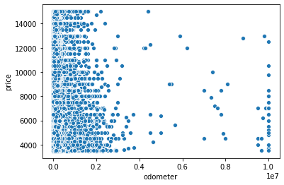

```python
data_odometer = Data[Data["odometer"].isnull() == False]
sns.scatterplot(x = "odometer", y = "price", palette = None, data = data_odometer)
```

- Odometer not affect the price

### 2.2 Price VS Latitude

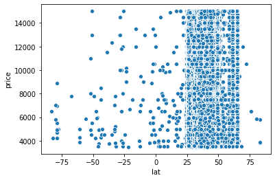

```python
data_lat = Data[Data["lat"].isnull() == False]
sns.scatterplot(x = "lat", y = "price", palette = None, data = data_lat)
```

- Latitude not affect the price

### 2.3 Price VS Longitude

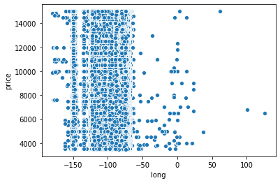

```python
data_long = Data[Data["long"].isnull() == False]
sns.scatterplot(x = "long", y = "price", palette = None, data = data_long)
```

- Langitude not affect the price

### 2.4 Proof using correlation test

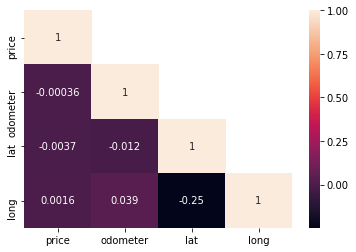

```python
corr = num_data.corr()
mask = np.array(corr)
mask[np.tril_indices_from(mask)] = False
sns.heatmap(corr, mask = mask, annot = True)
```

From all visualization above we can conclude that there are no numerical variable that affect the price

### 3. Year Analyzing

- By reading through the wikipedia page of Automotive industry in the United States, big changes were taking place in automobile development in the 1960s and the car sales grew to large number in that period. So, we reduce the dataset with drop the year < 1960.

```python
Data.drop(Data[Data.year < 1960].index, inplace = True)
```

### 3.1 Average Price VS Number of Cars

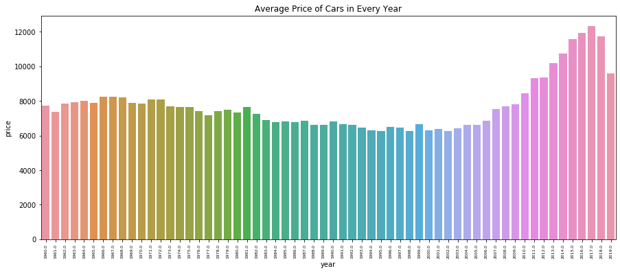

```python
con_price1 = Data[["year", "price"]].groupby("year").mean()["price"].sort_values(ascending = False)
plt.figure(figsize = (15,6))
sns.barplot(x = con_price1.index, y = con_price1)
plt.xticks(rotation = 90, fontsize = 6)
plt.title("Average Price of Cars in Every Year")
```

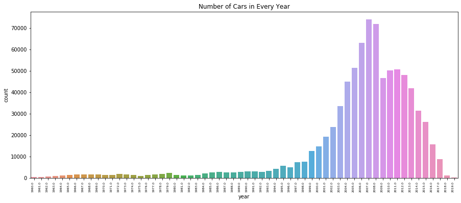

```python
plt.figure(figsize=(15,6))
ax = sns.countplot(x = "year", data = Data);
ax.set_xticklabels(ax.get_xticklabels(), rotation = 90, ha="right",fontsize = 6)
plt.title("Number of Cars in Every Year")
ax
```

- There are no relation between the price and the number of cars in every year

### 4. Price VS Number of Cars Based Some Categorical Variable

### 4.1 Manufacturer

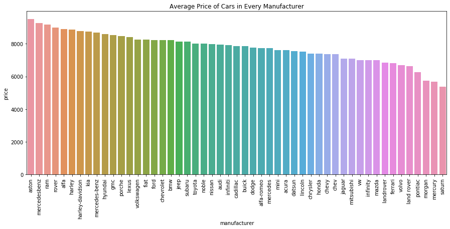

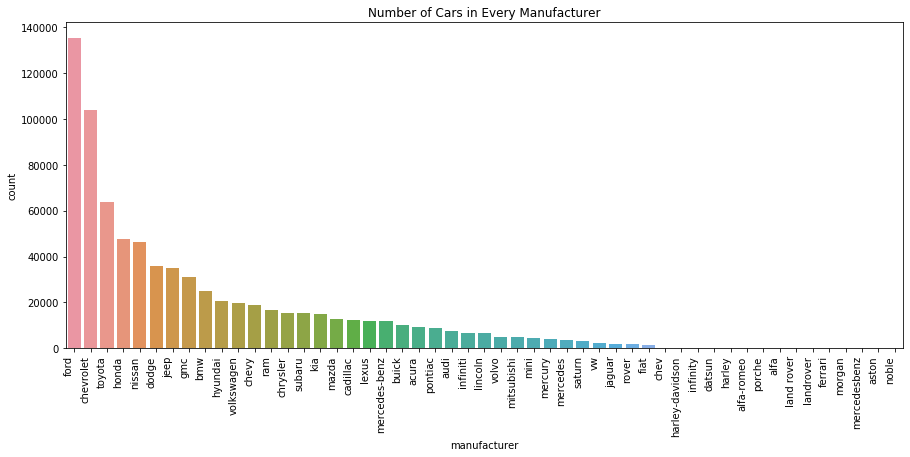

```python
plt.figure(figsize=(15,6))
data_manufacturer = Data[Data["manufacturer"].isnull() == False]
con_manufacturer = data_manufacturer[["manufacturer", "price"]].groupby("manufacturer").mean()["price"].sort_values(ascending = False)
plt.xticks(rotation = 90)
plt.title("Average Price of Cars in Every Manufacturer")
sns.barplot(x = con_manufacturer.index, y = con_manufacturer)

plt.figure(figsize=(15,6))
ax = sns.countplot(x = "manufacturer", data = Data, order = Data["manufacturer"].value_counts().index);
ax.set_xticklabels(ax.get_xticklabels(), rotation = 90, ha="right")
plt.title("Number of Cars in Every Manufacturer")
ax
```

### 4.2 Paint Color

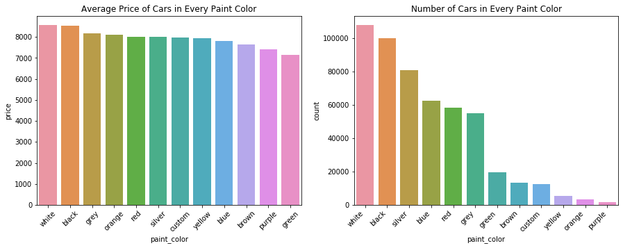

```python
f = plt.figure(figsize = (15,5))

f.add_subplot(1, 2, 1)
data_paint = Data[Data["paint_color"].isnull() == False]
con_paint = data_paint[["paint_color", "price"]].groupby("paint_color").mean()["price"].sort_values(ascending = False)
plt.xticks(rotation = 45)
plt.title("Average Price of Cars in Every Paint Color")
sns.barplot(x = con_paint.index, y = con_paint)

f.add_subplot(1, 2, 2)
ax = sns.countplot(x = "paint_color", data = Data, order = Data["paint_color"].value_counts().index);
ax.set_xticklabels(ax.get_xticklabels(), rotation = 45, ha="right")
plt.title("Number of Cars in Every Paint Color")
```

From the data above we can see that white and black colour paint of cars have high price and high number of sold.

### 4.3 Number of Cylinders

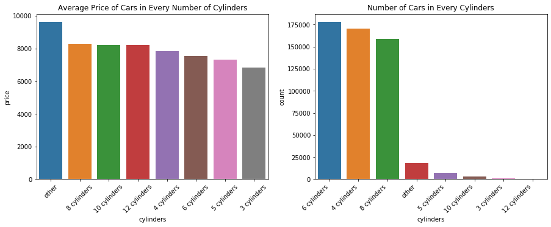

```python
f = plt.figure(figsize = (15,5))

f.add_subplot(1, 2, 1)
data_cylinders = Data[Data["cylinders"].isnull() == False]
con_cylinders = data_cylinders[["cylinders", "price"]].groupby("cylinders").mean()["price"].sort_values(ascending = False)
plt.xticks(rotation = 45)
plt.title("Average Price of Cars in Every Number of Cylinders")
sns.barplot(x = con_cylinders.index, y = con_cylinders)

f.add_subplot(1, 2, 2)
ax = sns.countplot(x = "cylinders", data = Data, order = Data["cylinders"].value_counts().index);
ax.set_xticklabels(ax.get_xticklabels(), rotation = 45, ha="right")
plt.title("Number of Cars in Every Cylinders")
```

### 4.4 Transmission

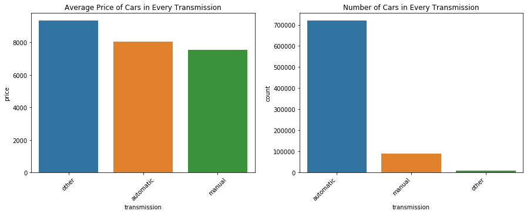

```python
f = plt.figure(figsize = (15,5))

f.add_subplot(1, 2, 1)
data_transmission = Data[Data["transmission"].isnull() == False]
con_transmission = data_transmission[["transmission", "price"]].groupby("transmission").mean()["price"].sort_values(ascending = False)
plt.xticks(rotation = 45)
plt.title("Average Price of Cars in Every Transmission")
sns.barplot(x = con_transmission.index, y = con_transmission)

f.add_subplot(1, 2, 2)
ax = sns.countplot(x = "transmission", data = Data, order = Data["transmission"].value_counts().index);
ax.set_xticklabels(ax.get_xticklabels(), rotation = 45, ha="right")
plt.title("Number of Cars in Every Transmission")
```

### 4.5 Type

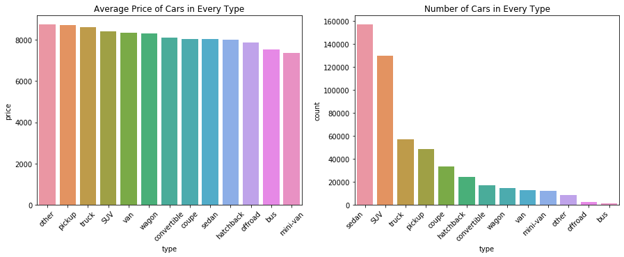

```python
f = plt.figure(figsize = (15,5))

f.add_subplot(1, 2, 1)
data_type = Data[Data["type"].isnull() == False]
con_type = data_type[["type", "price"]].groupby("type").mean()["price"].sort_values(ascending = False)
plt.xticks(rotation = 45)
plt.title("Average Price of Cars in Every Type")
sns.barplot(x = con_type.index, y = con_type)

f.add_subplot(1, 2, 2)
ax = sns.countplot(x = "type", data = Data, order = Data["type"].value_counts().index);
ax.set_xticklabels(ax.get_xticklabels(), rotation = 45, ha="right")
plt.title("Number of Cars in Every Type")
```

### 4.6 Condition

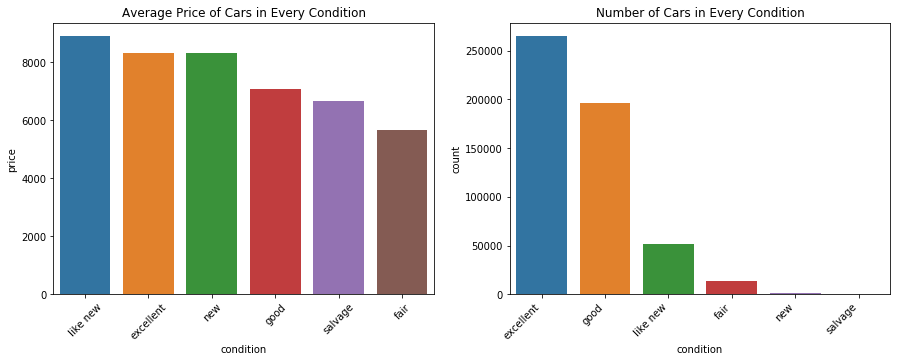

```python
f = plt.figure(figsize = (15,5))

f.add_subplot(1, 2, 1)
data_type = Data[Data["condition"].isnull() == False]
con_type = data_type[["condition", "price"]].groupby("condition").mean()["price"].sort_values(ascending = False)
plt.xticks(rotation = 45)
plt.title("Average Price of Cars in Every Condition")
sns.barplot(x = con_type.index, y = con_type)

f.add_subplot(1, 2, 2)
ax = sns.countplot(x = "condition", data = Data, order = Data["condition"].value_counts().index);
ax.set_xticklabels(ax.get_xticklabels(), rotation = 45, ha="right")
plt.title("Number of Cars in Every Condition")
```

### 4.7 Fuel

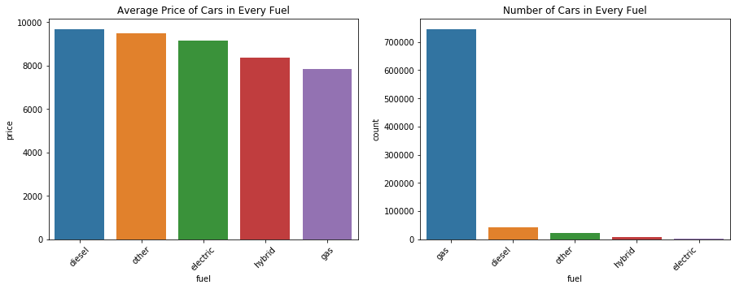

```python
f = plt.figure(figsize = (15,5))

f.add_subplot(1, 2, 1)
data_type = Data[Data["fuel"].isnull() == False]
con_type = data_type[["fuel", "price"]].groupby("fuel").mean()["price"].sort_values(ascending = False)
plt.xticks(rotation = 45)
plt.title("Average Price of Cars in Every Fuel")
sns.barplot(x = con_type.index, y = con_type)

f.add_subplot(1, 2, 2)
ax = sns.countplot(x = "fuel", data = Data, order = Data["fuel"].value_counts().index);
ax.set_xticklabels(ax.get_xticklabels(), rotation = 45, ha="right")
plt.title("Number of Cars in Every Fuel")
```

### 4.8 Drive

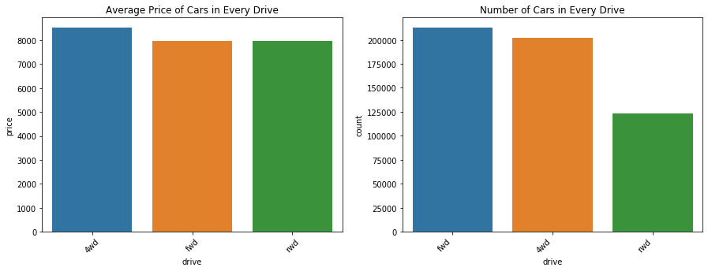

```python
f = plt.figure(figsize = (15,5))

f.add_subplot(1, 2, 1)
data_type = Data[Data["drive"].isnull() == False]
con_type = data_type[["drive", "price"]].groupby("drive").mean()["price"].sort_values(ascending = False)
plt.xticks(rotation = 45)
plt.title("Average Price of Cars in Every Drive")
sns.barplot(x = con_type.index, y = con_type)

f.add_subplot(1, 2, 2)
ax = sns.countplot(x = "drive", data = Data, order = Data["drive"].value_counts().index);
ax.set_xticklabels(ax.get_xticklabels(), rotation = 45, ha="right")
plt.title("Number of Cars in Every Drive")
```

# Conclusion

From all the steps we've done, we can concluded that we can get the important information from a data, but not all of the data we can take value from. How to clean data, selection of the statistical method and selection of how visualizations can greatly affect the results.